# Project: Wrangle And Analyze WeRateDogs Data

## Introduction

The dataset used in this analysis was taken from WeRateDogs Twitter Account. It was gathered using multiple resources and methods. The data was then assessed for quality and tidiness issues. Later on, cleaning operations were done on the data in order to provide useful insights through our analysis.

## Storing, Analyzing, Visualizing WeRateDogs Cleaned Data

During the cleaning operations, I have successfully stored all the clean information in a DataFrame. The final clean dataframe contained 1679 entries while the original dataset contained 2356. This final data was exported to a csv file named 'twitter_archive_master.csv'

Thereafter, I have analyzed the data for the most popular dog breeds. The top five breeds were Golden Retriever, Labrador Retriever, Pembroke, Chihuahua and Pug. Golden Retriever topped the list with occurance in 158 entries in the dataset.  
Further, I looked best rated breeds of dogs. The best rated dog breed was found to be Bouvier des Flanders. But the average ratings of top dog breeds are pretty close to one another.  
A positive correlation between the rating of dogs and number of retweets was also observed. However, it was not a very strong one. I chose a scatter type plot to represent the same. **The plot for the correlation between rating of dogs and number of retweets is shown below:**

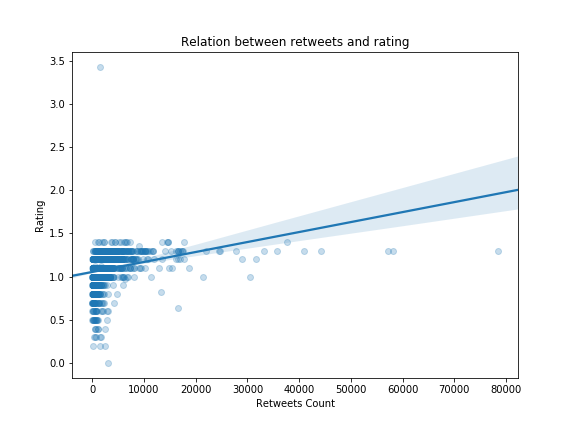

And finally, it was observed that the number of tweets have been declining over the years. **The plot of the number of tweets versus time is shown below:**

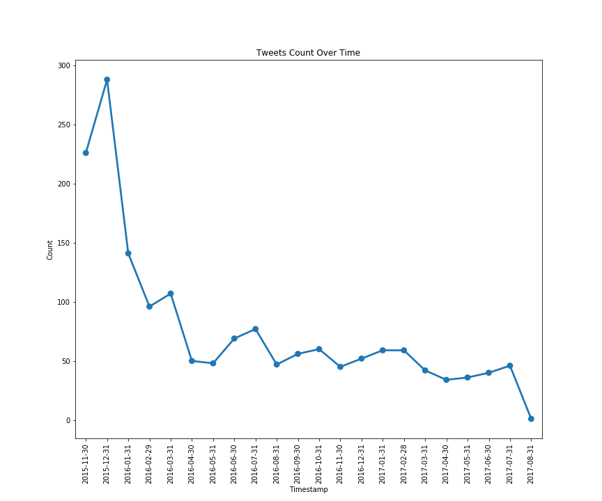